# Rhizosphere metabolome project - analysis of untargeted metabolomics data

Benjamin Delory

31/08/2020

This document details the R pipeline used to explore and analyse the metabolomics data presented in **Delory et al (2020) The rhizosphere metabolome triggers species-specific and context-dependent root responses in later arriving plants**.

# Load R packages

```r
library(randomForest)
library(missForest)
library(FactoMineR)
library(scatterplot3d)
library(GGally)
library(MASS)
library(emmeans)
library(rgl)
library(car)
library(gplots)
library(ggforce)
library(ggpubr)
library(hierDiversity)
library(ggplot2)
library(Boruta)
```

# Create R function for group-wise diversity partitioning

`diversity.partitioning` is an R function for group-wise diversity partitioning. It is entirely based on the complexity-as-diversity approach described in [Marion et al (2015). Extending the concept of diversity partitioning to characterize phenotypic complexity. The American Naturalist, 186, 348-361](https://www.journals.uchicago.edu/doi/10.1086/682369). This method relies on constructing diversity profile plots to visualise how effective diversity varies with diversity order (q). For each diversity order q, hierarchical partitioning is used to partition total effective chemical diversity (gamma diversity) into two components: alpha diversity (i.e., the average effective number of metabolites in a sample) and beta diversity (i.e., the effective number of completely distinct metabolomes present within a group). Diversity components are partitioned multiplicatively.

```r
diversity.partitioning<-function(x, group, reps=100, q=seq(0, 3 ,by=0.1)){

  #x is a data matrix of proportional chemical abundance with K columns (metabolites)
  #and N rows (samples)
  #NA values replaced with zeros for this analysis

  #group is a matrix with the different treatment levels (with columns L1 and L2)

  #reps is the number of bootstrap replicates to conduct for approximating uncertainty

  #q is a vector of diversity orders

  #Create dataframes to store results
  n<-length(q)*16
  results<-data.frame(q=rep(NA, n),
                      Treatment=rep(NA, n),
                      Diversity=rep(NA, n),
                      Value=rep(NA, n),
                      CIlow=rep(NA, n),
                      CIhigh=rep(NA, n))

  k<-0

  for (i in 1:length(q)){

    part<-hierDiversity(dat=x, group=group, reps=reps, quant = c(0.025, 0.975), q=q[i])

    results[(k+1):(k+16),]<-as.data.frame(cbind(rep(q[i], 16),
                                 rep(unique(group[,1]), each=4),
                                 rep(c("alpha","beta", "gamma","turnover"), 4),
                                 c(part$L1[[1]][1,1:4],
                                   part$L1[[2]][1,1:4],
                                   part$L1[[3]][1,1:4],
                                   part$L1[[4]][1,1:4]),
                                 c(part$L1[[1]][3,1:4],
                                   part$L1[[2]][3,1:4],
                                   part$L1[[3]][3,1:4],
                                   part$L1[[4]][3,1:4]),
                                 c(part$L1[[1]][4,1:4],
                                   part$L1[[2]][4,1:4],
                                   part$L1[[3]][4,1:4],
                                   part$L1[[4]][4,1:4])))

    k<-i*16}

  results<-as.data.frame(apply(results, 2, unlist))
  results$q<-as.numeric(as.character(results$q))
  results$Value<-as.numeric(as.character(results$Value))
  results$CIlow<-as.numeric(as.character(results$CIlow))
  results$CIhigh<-as.numeric(as.character(results$CIhigh))

  return(results)}
```

# Load metabolomics data in R

```r
#Load positive ionisation data
pos <- read.csv("C:/Users/Delory/Documents/GitHub/rhizometabolome/data/dd_max_heuristic_SN50_bw3_pos_1.csv", header=TRUE)

#Load negative ionisation data
neg <- read.csv("C:/Users/Delory/Documents/GitHub/rhizometabolome/data/dd_max_heuristic_SN50_bw3_neg_1.csv", header=TRUE)

#Load DOC data
doc <- read.csv("C:/Users/Delory/Documents/GitHub/rhizometabolome/data/DOC.csv", header=TRUE)

rownames(pos)<-paste("PC", pos$PC, "_mz", round(pos$mz, 1) , "_rt", round(pos$rt, 1), sep="")
rownames(neg)<-paste("PC", neg$PC, "_mz", round(neg$mz, 1) , "_rt", round(neg$rt, 1), sep="")

pos<-pos[,-c(1:13)]
neg<-neg[,-c(1:13)]
doc<-doc[c(21:30, 1:20),]
```

# Dissolved organic carbon concentration

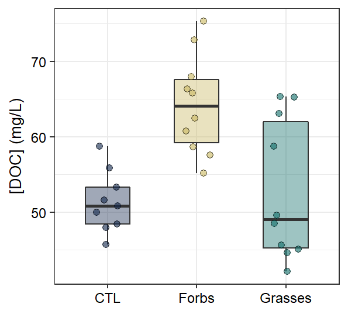

```r
doc1<-doc[-26,] #Remove CTL 6 (outlier)

yellow<-"#C9B75E"
green<-"#0C6C67"
blue<-"#11264B"

cbPalette <- c(blue, yellow, green)

cex.axis<-9
cex.title<-10
cex.pt<-1.7

ggplot(doc1, aes(x=Treatment, y=DOC, fill=Treatment))+
  geom_boxplot(alpha=0.4, outlier.shape = NA, width=0.5)+
  geom_jitter(aes(x=Treatment, y=DOC, fill=Treatment), shape=21, size=cex.pt, alpha=0.6,
              position=position_jitter(width=0.15))+
  theme_bw()+
  xlab("")+
  ylab("[DOC] (mg/L)")+
  theme(axis.title=element_text(size=cex.title, color="black", face="plain"),
        axis.title.y=element_text(margin = margin(r = 5)),
        axis.title.x=element_blank(),
        axis.text=element_text(size=cex.axis, color="black"),
        legend.position = "none")+
  scale_fill_manual(values=cbPalette)+
  scale_color_manual(values=cbPalette)
```

```r
model<-lm(DOC~Treatment, data=doc1)
anova(model)
```

```
## Analysis of Variance Table
##
## Response: DOC
##           Df  Sum Sq Mean Sq F value    Pr(>F)
## Treatment  2  977.94  488.97  9.8269 0.0006629 ***
## Residuals 26 1293.71   49.76
## ---
## Signif. codes:  0 '***' 0.001 '**' 0.01 '*' 0.05 '.' 0.1 ' ' 1
```

```r
summary(emmeans(model, "Treatment", contr="tukey"), type="response")
```

```
## $emmeans
##  Treatment emmean   SE df lower.CL upper.CL
##  CTL         51.4 2.35 26     46.6     56.2
##  Forbs       64.3 2.23 26     59.7     68.9
##  Grasses     52.8 2.23 26     48.2     57.4
##
## Confidence level used: 0.95
##
## $contrasts
##  contrast        estimate   SE df t.ratio p.value
##  CTL - Forbs       -12.91 3.24 26 -3.982  0.0014
##  CTL - Grasses      -1.42 3.24 26 -0.439  0.8994
##  Forbs - Grasses    11.48 3.15 26  3.640  0.0033
##
## P value adjustment: tukey method for comparing a family of 3 estimates
```

```r
doc.es<-aggregate(doc1$DOC, by=list(Treatment=doc1$Treatment), mean)
colnames(doc.es)[2]<-"DOC"
doc.es$ES<-100*(doc.es$DOC-doc.es$DOC[1])/doc.es$DOC[1]
knitr::kable(doc.es, caption="Mean DOC values (mg/L) for each treatment. Effect sizes (ES) provided in %.")
```

Mean DOC values (mg/L) for each treatment. Effect sizes (ES) provided in %.

| Treatment | DOC | ES |
| --- | --- | --- |
| CTL | 51.38893 | 0.000000 |
| Forbs | 64.29580 | 25.116061 |
| Grasses | 52.81333 | 2.771818 |

# Metabolite richness

```r
#Calculate metabolite richness for positive and negative ionisation data
mdiversity<-data.frame(Treatment=c(rep("Forbs", 10), rep("Grasses", 10), rep("CTL", 10), rep("Tap", 5)),
                       Richness.pos=as.numeric(apply(pos, 2, function(x){length(which(!is.na(x)))})),
                       Richness.neg=as.numeric(apply(neg, 2, function(x){length(which(!is.na(x)))})),
                       DOC=c(as.numeric(doc$DOC), rep(NA, 5)))

mdiversity<-mdiversity[-c(26,31:35),] #Remove CTL 6 (outlier) and Tap water samples
```

## Positive ionisation data

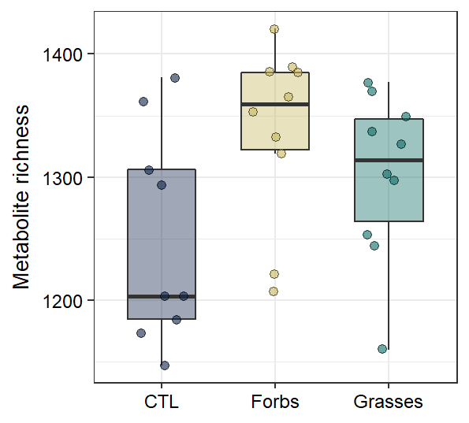

Metabolite richness (positive ionisation)

```r
yellow<-"#C9B75E"
green<-"#0C6C67"
blue<-"#11264B"

cbPalette <- c(blue, yellow, green)

cex.axis<-9
cex.title<-10
cex.pt<-1.7

p1<-ggplot(mdiversity, aes(x=Treatment, y=Richness.pos, fill=Treatment))+
  geom_boxplot(alpha=0.4, outlier.shape = NA, width=0.6)+
  geom_jitter(aes(x=Treatment, y=Richness.pos, fill=Treatment), shape=21, size=cex.pt, alpha=0.6,
              position=position_jitter(width=0.2))+
  theme_bw()+
  xlab("")+
  ylab("Metabolite richness")+
  theme(axis.title=element_text(size=cex.title, color="black", face="plain"),
        axis.title.y=element_text(margin = margin(t = 0, r = 5, b = 0, l = 0)),
        axis.title.x=element_blank(),
        axis.text=element_text(size=cex.axis, color="black"),
        legend.position = "none")+
  scale_fill_manual(values=cbPalette)+
  scale_color_manual(values=cbPalette)

p1
```

```r
#ggsave("Metabolite_richness.tiff", p1, dpi=1000, compression="lzw", width=7, height=8, units="cm")

#Statistics
model<-glm.nb(Richness.pos~Treatment, mdiversity) #Use negative binomial distribution because Poisson is overdispersed
summary(model)
```

```
##
## Call:
## glm.nb(formula = Richness.pos ~ Treatment, data = mdiversity,
##     init.theta = 439.7138793, link = log)
##
## Deviance Residuals:
##     Min       1Q   Median       3Q      Max
## -2.0385  -0.6857   0.2046   0.6670   1.8356
##
## Coefficients:
##                  Estimate Std. Error z value Pr(>|z|)
## (Intercept)       7.13090    0.01848 385.833   <2e-16 ***
## TreatmentForbs    0.06796    0.02537   2.678   0.0074 **
## TreatmentGrasses  0.04045    0.02541   1.592   0.1114
## ---
## Signif. codes:  0 '***' 0.001 '**' 0.01 '*' 0.05 '.' 0.1 ' ' 1
##
## (Dispersion parameter for Negative Binomial(439.7139) family taken to be 1)
##
##     Null deviance: 36.301  on 28  degrees of freedom
## Residual deviance: 29.095  on 26  degrees of freedom
## AIC: 338.06
##
## Number of Fisher Scoring iterations: 1
##
##
##               Theta:  440
##           Std. Err.:  155
##
##  2 x log-likelihood:  -330.064
```

```r
round(predict(model, newdata = data.frame(Treatment=c("CTL", "Forbs", "Grasses")), type="response"))
```

```
##    1    2    3
## 1250 1338 1302
```

```r
drop1(model, test="LRT")
```

```
## Single term deletions
##
## Model:
## Richness.pos ~ Treatment
##           Df Deviance    AIC   LRT Pr(>Chi)
## <none>         29.095 336.06
## Treatment  2   36.301 339.27 7.206  0.02724 *
## ---
## Signif. codes:  0 '***' 0.001 '**' 0.01 '*' 0.05 '.' 0.1 ' ' 1
```

```r
deviance<-100*(model$null.deviance-model$deviance)/model$null.deviance
deviance
```

```
## [1] 19.85057
```

```r
E1<-resid(model, type="pearson")
dispersion<-sum(E1^2)/(29-length(coef(model))-1)
dispersion
```

```
## [1] 1.150576
```

```r
summary(emmeans(model, "Treatment", contr="tukey"), type="response")
```

```
## $emmeans
##  Treatment response   SE  df asymp.LCL asymp.UCL
##  CTL           1250 23.1 Inf      1206      1296
##  Forbs         1338 23.3 Inf      1293      1384
##  Grasses       1302 22.7 Inf      1258      1347
##
## Confidence level used: 0.95
## Intervals are back-transformed from the log scale
##
## $contrasts
##  contrast        ratio     SE  df z.ratio p.value
##  CTL / Forbs     0.934 0.0237 Inf -2.678  0.0202
##  CTL / Grasses   0.960 0.0244 Inf -1.592  0.2492
##  Forbs / Grasses 1.028 0.0253 Inf  1.117  0.5035
##
## P value adjustment: tukey method for comparing a family of 3 estimates
## Tests are performed on the log scale
```

## Negative ionisation data

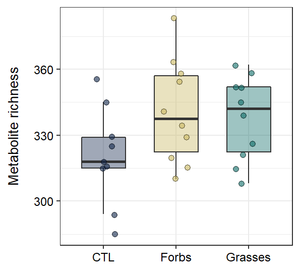

Metabolite richness (negative ionisation)

```r
yellow<-"#C9B75E"
green<-"#0C6C67"
blue<-"#11264B"

cbPalette <- c(blue, yellow, green)

cex.axis<-9
cex.title<-10
cex.pt<-1.7

ggplot(mdiversity, aes(x=Treatment, y=Richness.neg, fill=Treatment))+
  geom_boxplot(alpha=0.4, outlier.shape = NA, width=0.6)+
  geom_jitter(aes(x=Treatment, y=Richness.neg, fill=Treatment), shape=21, size=cex.pt, alpha=0.6,
              position=position_jitter(width=0.2))+
  theme_bw()+
  xlab("")+
  ylab("Metabolite richness")+
  theme(axis.title=element_text(size=cex.title, color="black", face="plain"),
        axis.title.y=element_text(margin = margin(t = 0, r = 10, b = 0, l = 0)),
        axis.title.x=element_blank(),
        axis.text=element_text(size=cex.axis, color="black"),
        legend.position = "none")+
  scale_fill_manual(values=cbPalette)+
  scale_color_manual(values=cbPalette)
```

```r
model<-glm.nb(Richness.neg~Treatment, mdiversity) #Use negative binomial distribution because Poisson is overdispersed
summary(model)
```

```
##
## Call:
## glm.nb(formula = Richness.neg ~ Treatment, data = mdiversity,
##     init.theta = 1292.864376, link = log)
##
## Deviance Residuals:
##      Min        1Q    Median        3Q       Max
## -1.80274  -0.82222   0.01446   0.68222   1.99023
##
## Coefficients:
##                  Estimate Std. Error z value Pr(>|z|)
## (Intercept)       5.76902    0.02081 277.266   <2e-16 ***
## TreatmentForbs    0.06199    0.02835   2.186   0.0288 *
## TreatmentGrasses  0.05344    0.02840   1.882   0.0598 .
## ---
## Signif. codes:  0 '***' 0.001 '**' 0.01 '*' 0.05 '.' 0.1 ' ' 1
##
## (Dispersion parameter for Negative Binomial(1292.864) family taken to be 1)
##
##     Null deviance: 34.530  on 28  degrees of freedom
## Residual deviance: 29.024  on 26  degrees of freedom
## AIC: 265.39
##
## Number of Fisher Scoring iterations: 1
##
##
##               Theta:  1293
##           Std. Err.:  1658
##
##  2 x log-likelihood:  -257.388
```

```r
deviance<-100*(model$null.deviance-model$deviance)/model$null.deviance
deviance
```

```
## [1] 15.94491
```

```r
E1<-resid(model, type="pearson")
dispersion<-sum(E1^2)/(29-length(coef(model))-1)
dispersion
```

```
## [1] 1.160883
```

```r
summary(emmeans(model, "Treatment", contr="tukey"), type="response")
```

```
## $emmeans
##  Treatment response   SE  df asymp.LCL asymp.UCL
##  CTL            320 6.66 Inf       307       334
##  Forbs          341 6.56 Inf       328       354
##  Grasses        338 6.53 Inf       325       351
##
## Confidence level used: 0.95
## Intervals are back-transformed from the log scale
##
## $contrasts
##  contrast        ratio     SE  df z.ratio p.value
##  CTL / Forbs     0.940 0.0266 Inf -2.186  0.0735
##  CTL / Grasses   0.948 0.0269 Inf -1.882  0.1439
##  Forbs / Grasses 1.009 0.0275 Inf  0.313  0.9473
##
## P value adjustment: tukey method for comparing a family of 3 estimates
## Tests are performed on the log scale
```

# Abundance-Diversity relationship

## Positive ionisation data

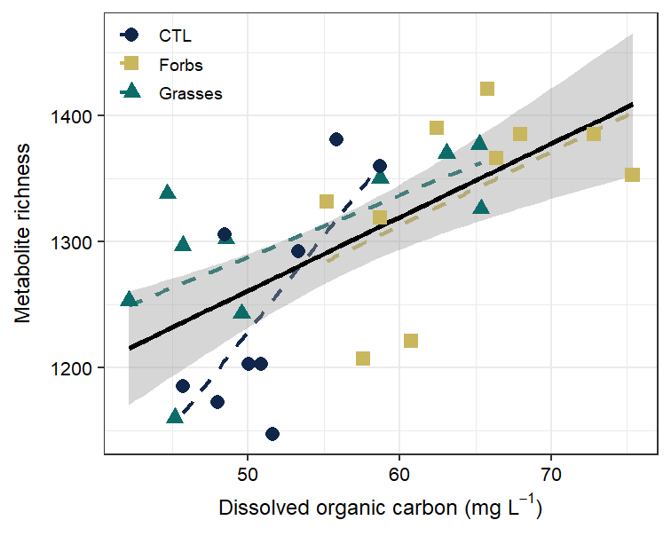

Abundance-Diversity relationship (positive ionisation data)

```r
yellow<-"#C9B75E"
green<-"#0C6C67"
blue<-"#11264B"

cbPalette <- c(blue, yellow, green)

cex.axis<-8
cex.title<-9
cex.pt<-1.5

p2<-ggplot(mdiversity, aes(x=DOC, y=Richness.pos, color=Treatment, shape=Treatment))+
  geom_smooth(method="lm", se=FALSE, linetype=2, size=0.8)+
  geom_smooth(data=mdiversity, mapping=aes(x=DOC, y=Richness.pos), inherit.aes = F, method="lm", color="black")+
  geom_point(size=2.5)+
  theme_bw()+
  xlab(expression(paste("Dissolved organic carbon (mg ", L^-1, ")")))+
  ylab("Metabolite richness")+
  theme(axis.title=element_text(size=cex.title, color="black", face="plain"),
        axis.title.y=element_text(margin = margin(t = 0, r = 7, b = 0, l = 0)),
        axis.text=element_text(size=cex.axis, color="black"),
        legend.position=c(0.12,0.9),
        legend.background = element_blank(),
        legend.key = element_blank(),
        legend.text=element_text(size=7),
        legend.key.size = unit(0.85,"line"),
        legend.title = element_blank())+
  scale_color_manual(values=cbPalette)+
  scale_shape_manual(values=c(16, 15, 17))

p2
```

```r
#ggsave("Abundance_diversity_metabolites.tiff", p2, dpi=1000, compression="lzw", width=10, height=8, units="cm")

cor.test(mdiversity$DOC, mdiversity$Richness.pos)
```

```
##
##  Pearson's product-moment correlation
##
## data:  mdiversity$DOC and mdiversity$Richness.pos
## t = 4.4362, df = 27, p-value = 0.0001385
## alternative hypothesis: true correlation is not equal to 0
## 95 percent confidence interval:
##  0.3711055 0.8205392
## sample estimates:
##       cor
## 0.6492986
```

```r
cor.test(mdiversity$DOC[mdiversity$Treatment=="CTL"], mdiversity$Richness.pos[mdiversity$Treatment=="CTL"])
```

```
##
##  Pearson's product-moment correlation
##
## data:  mdiversity$DOC[mdiversity$Treatment == "CTL"] and mdiversity$Richness.pos[mdiversity$Treatment == "CTL"]
## t = 2.7191, df = 7, p-value = 0.02981
## alternative hypothesis: true correlation is not equal to 0
## 95 percent confidence interval:
##  0.1003438 0.9355323
## sample estimates:
##      cor
## 0.716704
```

```r
cor.test(mdiversity$DOC[mdiversity$Treatment=="Forbs"], mdiversity$Richness.pos[mdiversity$Treatment=="Forbs"])
```

```
##
##  Pearson's product-moment correlation
##
## data:  mdiversity$DOC[mdiversity$Treatment == "Forbs"] and mdiversity$Richness.pos[mdiversity$Treatment == "Forbs"]
## t = 1.7971, df = 8, p-value = 0.11
## alternative hypothesis: true correlation is not equal to 0
## 95 percent confidence interval:
##  -0.1409395  0.8716025
## sample estimates:
##       cor
## 0.5362755
```

```r
cor.test(mdiversity$DOC[mdiversity$Treatment=="Grasses"], mdiversity$Richness.pos[mdiversity$Treatment=="Grasses"])
```

```
##
##  Pearson's product-moment correlation
##
## data:  mdiversity$DOC[mdiversity$Treatment == "Grasses"] and mdiversity$Richness.pos[mdiversity$Treatment == "Grasses"]
## t = 2.5747, df = 8, p-value = 0.03289
## alternative hypothesis: true correlation is not equal to 0
## 95 percent confidence interval:
##  0.07554875 0.91497976
## sample estimates:
##       cor
## 0.6731548
```

## Negative ionisation data

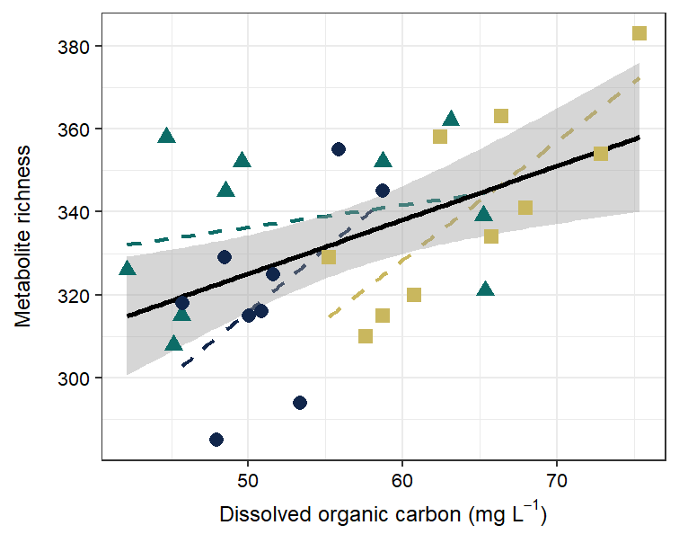

Abundance-Diversity relationship (negative ionisation data)

```r
yellow<-"#C9B75E"
green<-"#0C6C67"
blue<-"#11264B"

cbPalette <- c(blue, yellow, green)

cex.axis<-8
cex.title<-9
cex.pt<-1.5

ggplot(mdiversity, aes(x=DOC, y=Richness.neg, color=Treatment, shape=Treatment))+
  geom_smooth(method="lm", se=FALSE, linetype=2, size=0.8)+
  geom_smooth(data=mdiversity, mapping=aes(x=DOC, y=Richness.neg), inherit.aes = F, method="lm", color="black")+
  geom_point(size=2.5)+
  theme_bw()+
  xlab(expression(paste("Dissolved organic carbon (mg ", L^-1, ")")))+
  ylab("Metabolite richness")+
  theme(axis.title=element_text(size=cex.title, color="black", face="plain"),
        axis.title.y=element_text(margin = margin(t = 0, r = 10, b = 0, l = 0)),
        axis.text=element_text(size=cex.axis, color="black"),
        legend.position = "none")+
  scale_color_manual(values=cbPalette)+
  scale_shape_manual(values=c(16, 15, 17))
```

```r
cor.test(mdiversity$DOC, mdiversity$Richness.neg)
```

```
##
##  Pearson's product-moment correlation
##
## data:  mdiversity$DOC and mdiversity$Richness.neg
## t = 3.1161, df = 27, p-value = 0.004314
## alternative hypothesis: true correlation is not equal to 0
## 95 percent confidence interval:
##  0.1821270 0.7411125
## sample estimates:
##       cor
## 0.5143027
```

```r
cor.test(mdiversity$DOC[mdiversity$Treatment=="CTL"], mdiversity$Richness.neg[mdiversity$Treatment=="CTL"])
```

```
##
##  Pearson's product-moment correlation
##
## data:  mdiversity$DOC[mdiversity$Treatment == "CTL"] and mdiversity$Richness.neg[mdiversity$Treatment == "CTL"]
## t = 1.7967, df = 7, p-value = 0.1154
## alternative hypothesis: true correlation is not equal to 0
## 95 percent confidence interval:
##  -0.1632345  0.8928077
## sample estimates:
##       cor
## 0.5617895
```

```r
cor.test(mdiversity$DOC[mdiversity$Treatment=="Forbs"], mdiversity$Richness.neg[mdiversity$Treatment=="Forbs"])
```

```
##
##  Pearson's product-moment correlation
##
## data:  mdiversity$DOC[mdiversity$Treatment == "Forbs"] and mdiversity$Richness.neg[mdiversity$Treatment == "Forbs"]
## t = 3.7917, df = 8, p-value = 0.005299
## alternative hypothesis: true correlation is not equal to 0
## 95 percent confidence interval:
##  0.3471090 0.9511535
## sample estimates:
##       cor
## 0.8015561
```

```r
cor.test(mdiversity$DOC[mdiversity$Treatment=="Grasses"], mdiversity$Richness.neg[mdiversity$Treatment=="Grasses"])
```

```
##
##  Pearson's product-moment correlation
##
## data:  mdiversity$DOC[mdiversity$Treatment == "Grasses"] and mdiversity$Richness.neg[mdiversity$Treatment == "Grasses"]
## t = 0.76028, df = 8, p-value = 0.4689
## alternative hypothesis: true correlation is not equal to 0
## 95 percent confidence interval:
##  -0.4423383  0.7642936
## sample estimates:
##       cor
## 0.2595842
```

# Diversity partitioning

## Positive ionisation

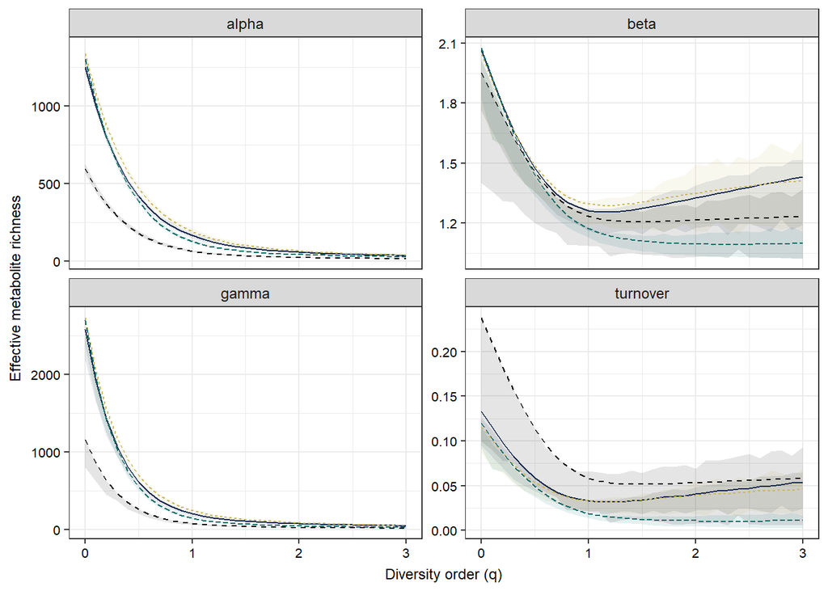

Diversity partitioning (positive ionisation data)

```r
pos.diversityplot<-t(pos)
pos.diversityplot[is.na(pos.diversityplot)]<-0
pos.diversityplot<-t(apply(pos.diversityplot, 1, function(x){x/sum(x)}))
pos.diversityplot<-pos.diversityplot[-26,] #Remove CTL 6 (outlier)

group<-as.matrix(data.frame(L1=c(rep("Forbs", 10), rep("Grasses", 10), rep("CTL", 9), rep("Tap", 5)), L2=rep("total", 34)))

pos.part<-diversity.partitioning(x=pos.diversityplot, group=group) #!time consuming!#
#Plot results
yellow<-"#C9B75E"
green<-"#0C6C67"
blue<-"#11264B"

cbPalette <- c(blue, yellow, green, "black")

cex.axis<-8
cex.title<-9
cex.strip<-9

ggplot(pos.part, aes(x=q, y=Value, color=Treatment))+
  facet_wrap(~Diversity, scales="free_y")+
  geom_ribbon(aes(x=q, ymin=CIlow, ymax=CIhigh, fill=Treatment), alpha=0.1, color=NA)+
  geom_line(aes(linetype=Treatment))+
  theme_bw()+
  xlab("Diversity order (q)")+
  ylab("Effective metabolite richness")+
  theme(axis.title=element_text(size=cex.title, color="black", face="plain"),
        axis.title.y=element_text(margin = margin(t = 0, r = 5, b = 0, l = 0)),
        axis.title.x=element_text(margin = margin(t = 5, r = 0, b = 0, l = 0)),
        axis.text=element_text(size=cex.axis, color="black"),
        legend.position = "none",
        strip.text = element_text(size=cex.strip))+
  scale_color_manual(values=cbPalette)+
  scale_fill_manual(values=cbPalette)
```

## Negative ionisation

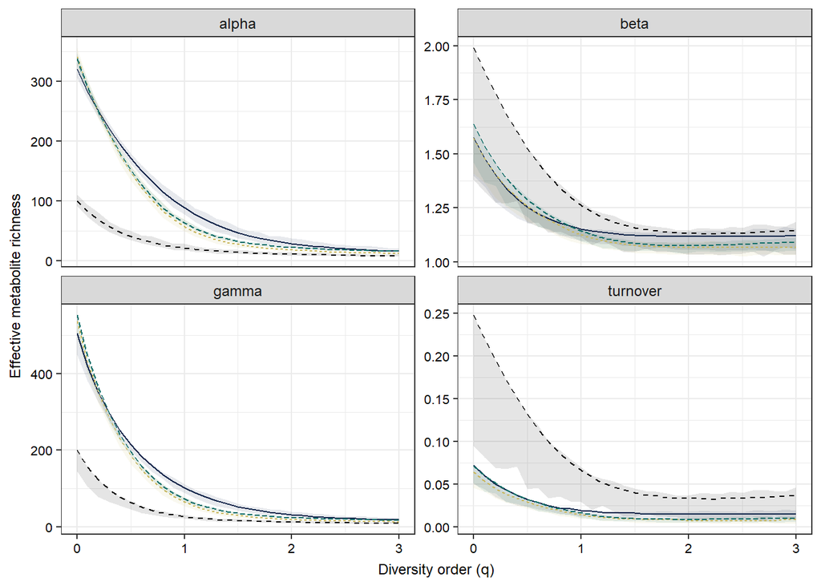

Diversity partitioning (negative ionisation data)

```r
neg.diversityplot<-t(neg)
neg.diversityplot[is.na(neg.diversityplot)]<-0
neg.diversityplot<-t(apply(neg.diversityplot, 1, function(x){x/sum(x)}))
neg.diversityplot<-neg.diversityplot[-26,] #Remove CTL 6 (outlier)

group<-as.matrix(data.frame(L1=c(rep("Forbs", 10), rep("Grasses", 10), rep("CTL", 9), rep("Tap", 5)), L2=rep("total", 34)))

neg.part<-diversity.partitioning(x=neg.diversityplot, group=group) #!time consuming!#
#Plot results
yellow<-"#C9B75E"
green<-"#0C6C67"
blue<-"#11264B"

cbPalette <- c(blue, yellow, green, "black")

cex.axis<-8
cex.title<-9
cex.strip<-9

ggplot(neg.part, aes(x=q, y=Value, color=Treatment))+
  facet_wrap(~Diversity, scales="free_y")+
  geom_ribbon(aes(x=q, ymin=CIlow, ymax=CIhigh, fill=Treatment), alpha=0.1, color=NA)+
  geom_line(aes(linetype=Treatment))+
  theme_bw()+
  xlab("Diversity order (q)")+
  ylab("Effective metabolite richness")+
  theme(axis.title=element_text(size=cex.title, color="black", face="plain"),
        axis.title.y=element_text(margin = margin(t = 0, r = 5, b = 0, l = 0)),
        axis.title.x=element_text(margin = margin(t = 5, r = 0, b = 0, l = 0)),
        axis.text=element_text(size=cex.axis, color="black"),
        legend.position = "none",
        strip.text = element_text(size=cex.strip))+
  scale_color_manual(values=cbPalette)+
  scale_fill_manual(values=cbPalette)
```

# Data processing

## Remove constant features

Features with a constant or single value across samples were found and removed from the dataset.

```r
#Remove tap water samples
pos<-as.data.frame(pos[,-c(31:35)])
neg<-as.data.frame(neg[,-c(31:35)])

#Check
varCol <- apply(t(pos), 2, var, na.rm=T)
constCol <- (varCol == 0 | is.na(varCol))
constNum <- sum(constCol, na.rm=T)
if(constNum > 0){
  message(paste("Positive ionization:", constNum, "features with a constant or single value across samples were found and deleted."))
  pos <- pos[!constCol,,drop=FALSE]}
```

```
## Positive ionization: 265 features with a constant or single value across samples were found and deleted.
```

```r
varCol <- apply(t(neg), 2, var, na.rm=T)
constCol <- (varCol == 0 | is.na(varCol))
constNum <- sum(constCol, na.rm=T)
if(constNum > 0){
  message(paste("Negative ionization:", constNum, "features with a constant or single value across samples were found and deleted."))
  neg <- neg[!constCol,,drop=FALSE]}
```

```
## Negative ionization: 34 features with a constant or single value across samples were found and deleted.
```

## Detect zeros and NAs

```r
totalCount <- nrow(pos)*ncol(pos)
naCount <- sum(is.na(pos))
naPercent <- round(100*naCount/totalCount, 1)
message(paste("Positive ionization: A total of ", naCount, " (", naPercent, "%) missing values were detected.", sep=""))
```

```
## Positive ionization: A total of 48184 (55.4%) missing values were detected.
```

```r
totalCount <- nrow(neg)*ncol(neg)
naCount <- sum(is.na(neg))
naPercent <- round(100*naCount/totalCount, 1)
message(paste("Negative ionization: A total of ", naCount, " (", naPercent, "%) missing values were detected.", sep=""))
```

```
## Negative ionization: A total of 7348 (42.4%) missing values were detected.
```

## Impute missing values

Missing values were imputed using a random forest algorithm.

```r
set.seed(2) #For reproducibility
impute.pos<-missForest(t(pos), maxiter=10, ntree=500, verbose=TRUE)
```

```
##   missForest iteration 1 in progress...done!
##     estimated error(s): 0.1446113
##     difference(s): 0.000887263
##     time: 205.89 seconds
##
##   missForest iteration 2 in progress...done!
##     estimated error(s): 0.1421318
##     difference(s): 0.000157914
##     time: 223.07 seconds
##
##   missForest iteration 3 in progress...done!
##     estimated error(s): 0.1440248
##     difference(s): 4.762112e-05
##     time: 223.7 seconds
##
##   missForest iteration 4 in progress...done!
##     estimated error(s): 0.1453845
##     difference(s): 3.251679e-05
##     time: 222.58 seconds
##
##   missForest iteration 5 in progress...done!
##     estimated error(s): 0.1438554
##     difference(s): 2.711469e-05
##     time: 222.23 seconds
##
##   missForest iteration 6 in progress...done!
##     estimated error(s): 0.1437392
##     difference(s): 5.417035e-05
##     time: 222.1 seconds
```

```r
newpos<-impute.pos$ximp

set.seed(2) #For reproducibility
impute.neg<-missForest(t(neg), maxiter=10, ntree=500, verbose=TRUE)
```

```
##   missForest iteration 1 in progress...done!
##     estimated error(s): 0.1904921
##     difference(s): 0.003480998
##     time: 17.97 seconds
##
##   missForest iteration 2 in progress...done!
##     estimated error(s): 0.1844841
##     difference(s): 0.0003139473
##     time: 19.23 seconds
##
##   missForest iteration 3 in progress...done!
##     estimated error(s): 0.1870139
##     difference(s): 5.718283e-05
##     time: 19.38 seconds
##
##   missForest iteration 4 in progress...done!
##     estimated error(s): 0.185289
##     difference(s): 2.849411e-05
##     time: 19.33 seconds
##
##   missForest iteration 5 in progress...done!
##     estimated error(s): 0.1859347
##     difference(s): 3.254894e-05
##     time: 19.29 seconds
```

```r
newneg<-impute.neg$ximp
```

## Data normalization

Peak intensity values were normalized based on dissolved organic concentration (DOC) values.

```r
tnewpos<-t(newpos)
tnewneg<-t(newneg)

for (i in 1:nrow(tnewpos)){tnewpos[i,]<-as.numeric(1000*tnewpos[i,]/doc$DOC)}
for (i in 1:nrow(tnewneg)){tnewneg[i,]<-as.numeric(1000*tnewneg[i,]/doc$DOC)}
```

## Data transformation

Normalized data were transformed using a generalized logarithmic transformation.

```r
tnewpos<-log2((tnewpos+sqrt(tnewpos^2+1))/2)
tnewneg<-log2((tnewneg+sqrt(tnewneg^2+1))/2)
```

# Principal component analysis

Positive and negative ionisation data were merged for principal component analysis.

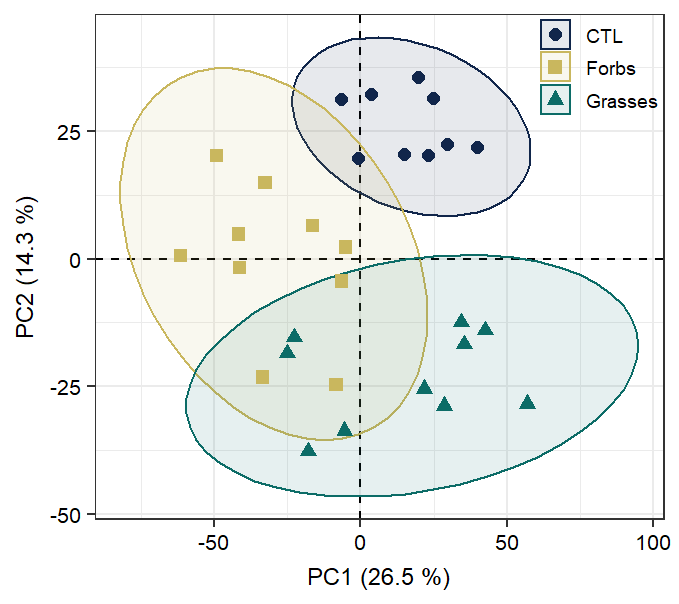

Principal component analysis

```r
newpos<-t(tnewpos)
newneg<-t(tnewneg)

newpos<-newpos[-26,] #Remove soil 6 (outlier)
newneg<-newneg[-26,] #Remove soil 6 (outlier)

colnames(newpos)<-paste(colnames(newpos), "_pos", sep="")
colnames(newneg)<-paste(colnames(newneg), "_neg", sep="")
alldata<-cbind(newpos, newneg)

#Do PCA
pca<-PCA(alldata, ncp=5, scale.unit = TRUE, graph = FALSE)
scores<-data.frame(Treatment=c(rep("Forbs", 10), rep("Grasses", 10), rep("CTL", 9)), pca$ind$coord)

yellow<-"#C9B75E"
green<-"#0C6C67"
blue<-"#11264B"

cbPalette <- c(blue, yellow, green)

cex.axis<-8
cex.title<-9
cex.pt<-2

p3<-ggplot(scores, aes(x=Dim.1, y=Dim.2, color=Treatment, shape=Treatment, fill=Treatment))+
    theme_bw()+
    geom_hline(yintercept=0, linetype=2)+
    geom_vline(xintercept=0, linetype=2)+
    stat_ellipse(geom="polygon", alpha=0.1)+
    geom_point(size=cex.pt)+
    scale_color_manual(values=cbPalette, name="Treatment")+
    scale_fill_manual(values=cbPalette, name="Treatment")+
    scale_shape_manual(values=c(16, 15, 17), name="Treatment")+
    xlab(paste("PC1 (", round(pca$eig[1,2], 1) ," %)", sep=""))+
    ylab(paste("PC2 (", round(pca$eig[2,2], 1) ," %)", sep=""))+
    theme(axis.title=element_text(size=cex.title, color="black", face="plain"),
          axis.title.y=element_text(margin = margin(t = 0, r = 5, b = 0, l = 0)),
          axis.title.x=element_text(margin = margin(t = 5, r = 0, b = 0, l = 0)),
          axis.text=element_text(size=cex.axis, color="black"),
          strip.text = element_text(size=cex.title, face="italic"),
          strip.background=element_rect(color="black"),
          legend.position=c(0.885,0.91),
          legend.background = element_blank(),
          legend.key = element_blank(),
          legend.text=element_text(size=7),
          legend.key.size = unit(0.85,"line"),
          legend.title = element_blank())

p3
```

```r
#ggsave("PCA_positive+negative.tiff", p3, dpi=1000, compression="lzw", width=9, height=8, units="cm")

scatter3d(x=scores$Dim.1, y=scores$Dim.2, z=scores$Dim.3, groups=scores$Treatment,
          surface=FALSE, grid=TRUE, ellipsoid=TRUE, fill=TRUE,
          surface.col=cbPalette,
          xlab=paste("PC1 (", round(pca$eig[1,2], 1) ," %)", sep=""),
          zlab=paste("PC3 (", round(pca$eig[3,2], 1) ," %)", sep=""),
          ylab=paste("PC2 (", round(pca$eig[2,2], 1) ," %)", sep=""),
          axis.col=rep("black", 3), sphere.size = 0.5, axis.scales = FALSE)

#rgl.snapshot(filename="PCA_3D.png")
```

# Create Figure 2

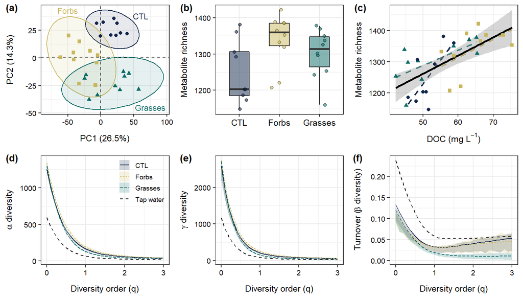

Figure 2

```r
yellow<-"#C9B75E"
green<-"#0C6C67"
blue<-"#11264B"

cbPalette <- c(blue, yellow, green)

cex.axis<-8
cex.title<-9.5
cex.pt<-1.5

#Plot PCA
p1<-ggplot(scores, aes(x=Dim.1, y=Dim.2, color=Treatment, shape=Treatment, fill=Treatment))+
  theme_bw()+
  geom_hline(yintercept=0, linetype=2)+
  geom_vline(xintercept=0, linetype=2)+
  stat_ellipse(geom="polygon", alpha=0.1)+
  geom_point(size=cex.pt)+
  scale_color_manual(values=cbPalette, name="Treatment")+
  scale_fill_manual(values=cbPalette, name="Treatment")+
  scale_shape_manual(values=c(16, 15, 17), name="Treatment")+
  xlab(paste("PC1 (", round(pca$eig[1,2], 1) ,"%)", sep=""))+
  ylab(paste("PC2 (", round(pca$eig[2,2], 1) ,"%)", sep=""))+
  theme(axis.title=element_text(size=cex.title, color="black", face="plain"),
        axis.title.y=element_text(margin = margin(t = 0, r = 5, b = 0, l = 0)),
        axis.title.x=element_text(margin = margin(t = 5, r = 0, b = 0, l = 0)),
        axis.text=element_text(size=cex.axis, color="black"),
        strip.text = element_text(size=cex.title, face="italic"),
        strip.background=element_rect(color="black"),
        legend.position="none")+
  annotate("text", x=60, y=38, label="CTL", size=3, color=blue)+
  annotate("text", x=-50, y=43, label="Forbs", size=3, color=yellow)+
  annotate("text", x=75, y=-45, label="Grasses", size=3, color=green)

#Plot metabolite richness
p2<-ggplot(mdiversity, aes(x=Treatment, y=Richness.pos, fill=Treatment))+
  geom_boxplot(alpha=0.5, outlier.shape = NA, width=0.5)+
  geom_jitter(aes(x=Treatment, y=Richness.pos, fill=Treatment), shape=21, size=cex.pt, alpha=0.6,
              position=position_jitter(width=0.2))+
  theme_bw()+
  xlab("")+
  ylab("Metabolite richness")+
  theme(axis.title=element_text(size=cex.title, color="black", face="plain"),
        axis.title.y=element_text(margin = margin(t = 0, r = 5, b = 0, l = 0)),
        axis.title.x=element_blank(),
        axis.text=element_text(size=cex.axis, color="black"),
        axis.text.x=element_text(size=cex.title, color="black"),
        legend.position = "none")+
  scale_fill_manual(values=cbPalette)+
  scale_color_manual(values=cbPalette)

#Plot abundance-diversity relationship
p3<-ggplot(mdiversity, aes(x=DOC, y=Richness.pos, color=Treatment, shape=Treatment))+
  geom_smooth(method="lm", se=FALSE, linetype=2, size=0.8)+
  geom_smooth(data=mdiversity, mapping=aes(x=DOC, y=Richness.pos), inherit.aes = F, method="lm", color="black")+
  geom_point(size=cex.pt)+
  theme_bw()+
  xlab(expression(paste("DOC (mg ", L^-1, ")")))+
  ylab("Metabolite richness")+
  theme(axis.title=element_text(size=cex.title, color="black", face="plain"),
        axis.title.y=element_text(margin = margin(t = 0, r = 5, b = 0, l = 0)),
        axis.title.x=element_text(margin = margin(t = 5, r = 0, b = 0, l = 0)),
        axis.text=element_text(size=cex.axis, color="black"),
        legend.position="none")+
  scale_color_manual(values=cbPalette)+
  scale_shape_manual(values=c(16, 15, 17))

#Plot alpha diversity
alpha<-pos.part[pos.part$Diversity=="alpha",]
levels(alpha$Treatment)[levels(alpha$Treatment)=="Tap"] <- "Tap water"

p4<-ggplot(alpha, aes(x=q, y=Value, color=Treatment))+
  geom_ribbon(aes(x=q, ymin=CIlow, ymax=CIhigh, fill=Treatment, alpha=Treatment), color=NA)+
  geom_line(aes(linetype=Treatment))+
  theme_bw()+
  xlab("Diversity order (q)")+
  ylab(expression(paste(alpha, " diversity", sep="")))+
  theme(axis.title=element_text(size=cex.title, color="black", face="plain"),
        axis.title.y=element_text(margin = margin(t = 0, r = 5, b = 0, l = 0)),
        axis.title.x=element_text(margin = margin(t = 5, r = 0, b = 0, l = 0)),
        axis.text=element_text(size=cex.axis, color="black"),
        legend.position=c(0.78,0.78),
        legend.background = element_blank(),
        legend.key = element_blank(),
        legend.text=element_text(size=7),
        legend.key.size = unit(0.85,"line"),
        legend.title = element_blank())+
  scale_fill_manual(values=c(cbPalette, "black"))+
  scale_color_manual(values=c(cbPalette, "black"))+
  scale_alpha_manual(values=c(0.2,0.2,0.2,0))

#Plot gamma diversity
gamma<-pos.part[pos.part$Diversity=="gamma",]
levels(gamma$Treatment)[levels(gamma$Treatment)=="Tap"] <- "Tap water"

p5<-ggplot(gamma, aes(x=q, y=Value, color=Treatment))+
  geom_ribbon(aes(x=q, ymin=CIlow, ymax=CIhigh, fill=Treatment, alpha=Treatment), color=NA)+
  geom_line(aes(linetype=Treatment))+
  theme_bw()+
  xlab("Diversity order (q)")+
  ylab(expression(paste(gamma, " diversity", sep="")))+
  theme(axis.title=element_text(size=cex.title, color="black", face="plain"),
        axis.title.y=element_text(margin = margin(t = 0, r = 5, b = 0, l = 0)),
        axis.title.x=element_text(margin = margin(t = 5, r = 0, b = 0, l = 0)),
        axis.text=element_text(size=cex.axis, color="black"),
        legend.position = "none")+
  scale_fill_manual(values=c(cbPalette,"black"))+
  scale_color_manual(values=c(cbPalette,"black"))+
  scale_alpha_manual(values=c(0.2,0.2,0.2,0))

#Plot turnover
turnover<-pos.part[pos.part$Diversity=="turnover",]
levels(turnover$Treatment)[levels(turnover$Treatment)=="Tap"] <- "Tap water"

p6<-ggplot(turnover, aes(x=q, y=Value, color=Treatment))+
  geom_ribbon(aes(x=q, ymin=CIlow, ymax=CIhigh, fill=Treatment, alpha=Treatment), color=NA)+
  geom_line(aes(linetype=Treatment))+
  theme_bw()+
  xlab("Diversity order (q)")+
  ylab(expression(paste("Turnover (", beta, " diversity)", sep="")))+
  theme(axis.title=element_text(size=cex.title, color="black", face="plain"),
        axis.title.y=element_text(margin = margin(t = 0, r = 5, b = 0, l = 0)),
        axis.title.x=element_text(margin = margin(t = 5, r = 0, b = 0, l = 0)),
        axis.text=element_text(size=cex.axis, color="black"),
        legend.position = "none")+
  scale_fill_manual(values=c(cbPalette,"black"))+
  scale_color_manual(values=c(cbPalette,"black"))+
  scale_alpha_manual(values=c(0.2,0.2,0.2,0))

#Create figure
p<-ggarrange(p1,p2,p3,p4,p5,p6, nrow=2, ncol=3, align="hv", labels=c("(a)","(b)","(c)","(d)","(e)", "(f)"), font.label = list(size=10.5))

p
```

```r
#ggsave("Figure2.tiff", p, dpi=1000, compression="lzw", width=20, height=11.5, units="cm")
```

# Create Figure S4

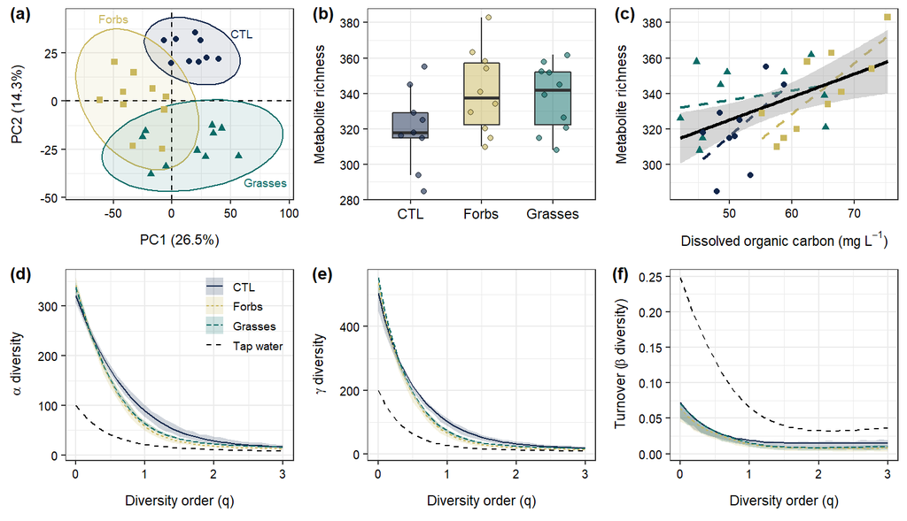

Figure S4

```r
yellow<-"#C9B75E"
green<-"#0C6C67"
blue<-"#11264B"

cbPalette <- c(blue, yellow, green)

cex.axis<-7.5
cex.title<-8.5
cex.pt<-1.5

#Plot PCA
p1<-ggplot(scores, aes(x=Dim.1, y=Dim.2, color=Treatment, shape=Treatment, fill=Treatment))+
  theme_bw()+
  geom_hline(yintercept=0, linetype=2)+
  geom_vline(xintercept=0, linetype=2)+
  stat_ellipse(geom="polygon", alpha=0.1)+
  geom_point(size=cex.pt)+
  scale_color_manual(values=cbPalette, name="Treatment")+
  scale_fill_manual(values=cbPalette, name="Treatment")+
  scale_shape_manual(values=c(16, 15, 17), name="Treatment")+
  xlab(paste("PC1 (", round(pca$eig[1,2], 1) ,"%)", sep=""))+
  ylab(paste("PC2 (", round(pca$eig[2,2], 1) ,"%)", sep=""))+
  theme(axis.title=element_text(size=cex.title, color="black", face="plain"),
        axis.title.y=element_text(margin = margin(t = 0, r = 5, b = 0, l = 0)),
        axis.title.x=element_text(margin = margin(t = 5, r = 0, b = 0, l = 0)),
        axis.text=element_text(size=cex.axis, color="black"),
        strip.text = element_text(size=cex.title, face="italic"),
        strip.background=element_rect(color="black"),
        legend.position="none")+
  annotate("text", x=60, y=35, label="CTL", size=2.5, color=blue)+
  annotate("text", x=-50, y=43, label="Forbs", size=2.5, color=yellow)+
  annotate("text", x=80, y=-42, label="Grasses", size=2.5, color=green)

#Plot metabolite richness
p2<-ggplot(mdiversity, aes(x=Treatment, y=Richness.neg, fill=Treatment))+
  geom_boxplot(alpha=0.5, outlier.shape = NA, width=0.5)+
  geom_jitter(aes(x=Treatment, y=Richness.neg, fill=Treatment), shape=21, size=cex.pt, alpha=0.6,
              position=position_jitter(width=0.2))+
  theme_bw()+
  xlab("")+
  ylab("Metabolite richness")+
  theme(axis.title=element_text(size=cex.title, color="black", face="plain"),
        axis.title.y=element_text(margin = margin(t = 0, r = 5, b = 0, l = 0)),
        axis.title.x=element_blank(),
        axis.text=element_text(size=cex.axis, color="black"),
        axis.text.x=element_text(size=cex.title, color="black"),
        legend.position = "none")+
  scale_fill_manual(values=cbPalette)+
  scale_color_manual(values=cbPalette)

#Plot abundance-diversity relationship
p3<-ggplot(mdiversity, aes(x=DOC, y=Richness.neg, color=Treatment, shape=Treatment))+
  geom_smooth(method="lm", se=FALSE, linetype=2, size=0.8)+
  geom_smooth(data=mdiversity, mapping=aes(x=DOC, y=Richness.neg), inherit.aes = F, method="lm", color="black")+
  geom_point(size=cex.pt)+
  theme_bw()+
  xlab(expression(paste("Dissolved organic carbon (mg ", L^-1, ")")))+
  ylab("Metabolite richness")+
  theme(axis.title=element_text(size=cex.title, color="black", face="plain"),
        axis.title.y=element_text(margin = margin(t = 0, r = 5, b = 0, l = 0)),
        axis.title.x=element_text(margin = margin(t = 5, r = 0, b = 0, l = 0)),
        axis.text=element_text(size=cex.axis, color="black"),
        legend.position="none")+
  scale_color_manual(values=cbPalette)+
  scale_shape_manual(values=c(16, 15, 17))

#Plot alpha diversity
alpha<-neg.part[neg.part$Diversity=="alpha",]
levels(alpha$Treatment)[levels(alpha$Treatment)=="Tap"] <- "Tap water"

p4<-ggplot(alpha, aes(x=q, y=Value, color=Treatment))+
  geom_ribbon(aes(x=q, ymin=CIlow, ymax=CIhigh, fill=Treatment, alpha=Treatment), color=NA)+
  geom_line(aes(linetype=Treatment))+
  theme_bw()+
  xlab("Diversity order (q)")+
  ylab(expression(paste(alpha, " diversity", sep="")))+
  theme(axis.title=element_text(size=cex.title, color="black", face="plain"),
        axis.title.y=element_text(margin = margin(t = 0, r = 5, b = 0, l = 0)),
        axis.title.x=element_text(margin = margin(t = 5, r = 0, b = 0, l = 0)),
        axis.text=element_text(size=cex.axis, color="black"),
        legend.position=c(0.78,0.78),
        legend.background = element_blank(),
        legend.key = element_blank(),
        legend.text=element_text(size=7),
        legend.key.size = unit(0.85,"line"),
        legend.title = element_blank())+
  scale_fill_manual(values=c(cbPalette, "black"))+
  scale_color_manual(values=c(cbPalette, "black"))+
  scale_alpha_manual(values=c(0.2,0.2,0.2,0))

#Plot gamma diversity
gamma<-neg.part[neg.part$Diversity=="gamma",]
levels(gamma$Treatment)[levels(gamma$Treatment)=="Tap"] <- "Tap water"

p5<-ggplot(gamma, aes(x=q, y=Value, color=Treatment))+
  geom_ribbon(aes(x=q, ymin=CIlow, ymax=CIhigh, fill=Treatment, alpha=Treatment), color=NA)+
  geom_line(aes(linetype=Treatment))+
  theme_bw()+
  xlab("Diversity order (q)")+
  ylab(expression(paste(gamma, " diversity", sep="")))+
  theme(axis.title=element_text(size=cex.title, color="black", face="plain"),
        axis.title.y=element_text(margin = margin(t = 0, r = 5, b = 0, l = 0)),
        axis.title.x=element_text(margin = margin(t = 5, r = 0, b = 0, l = 0)),
        axis.text=element_text(size=cex.axis, color="black"),
        legend.position = "none")+
  scale_fill_manual(values=c(cbPalette,"black"))+
  scale_color_manual(values=c(cbPalette,"black"))+
  scale_alpha_manual(values=c(0.2,0.2,0.2,0))

#Plot turnover
turnover<-neg.part[neg.part$Diversity=="turnover",]
levels(turnover$Treatment)[levels(turnover$Treatment)=="Tap"] <- "Tap water"

p6<-ggplot(turnover, aes(x=q, y=Value, color=Treatment))+
  geom_ribbon(aes(x=q, ymin=CIlow, ymax=CIhigh, fill=Treatment, alpha=Treatment), color=NA)+
  geom_line(aes(linetype=Treatment))+
  theme_bw()+
  xlab("Diversity order (q)")+
  ylab(expression(paste("Turnover (", beta, " diversity)", sep="")))+
  theme(axis.title=element_text(size=cex.title, color="black", face="plain"),
        axis.title.y=element_text(margin = margin(t = 0, r = 5, b = 0, l = 0)),
        axis.title.x=element_text(margin = margin(t = 5, r = 0, b = 0, l = 0)),
        axis.text=element_text(size=cex.axis, color="black"),
        legend.position = "none")+
  scale_fill_manual(values=c(cbPalette,"black"))+
  scale_color_manual(values=c(cbPalette,"black"))+
  scale_alpha_manual(values=c(0.2,0.2,0.2,0))

#Create figure
p<-ggarrange(p1,p2,p3,p4,p5,p6, nrow=2, ncol=3, align="hv", labels=c("(a)","(b)","(c)","(d)","(e)", "(f)"), font.label = list(size=10.5))

p
```

```r
#ggsave("FigureS4.tiff", p, dpi=1000, compression="lzw", width=20, height=11.5, units="cm")
```

# Discriminant metabolites

Detection of the most dicriminant metabolites was performed using a random forest approach. First, a random forest model was fitted to metabolomics data using 1000 trees and a combination of model hyperparameters that minimised the out-of-bag error. Second, the most discriminant features were detected using the [Boruta](https://cran.r-project.org/web/packages/Boruta/Boruta.pdf) R package.

## Tune model hyperparameters

```r
data_train<-data.frame(Treatment=as.character(sapply(rownames(newpos), function(x){strsplit(x, "_")[[1]][1]})), newpos, newneg)

#Tune model hyperparameters (ntree, mtry, nodesize, sampsize)
#Best model selected based on OOB error ("out of bag")
#!This is time consuming!

#Number of variables randomly sampled as candidates at each split.
mtry <- seq(50, 300, 50)
#Minimum size of terminal nodes. Setting this number larger causes smaller trees to be grown (and thus takes less time).
nodesize <- seq(1, 51, 10)
#Size(s) of sample to draw.
sampsize <- seq(15, 25, 2)

hyper_grid <- expand.grid(mtry = mtry, nodesize = nodesize, sampsize = sampsize)

oob_err <- c()

#pb <- txtProgressBar(min = 1, max = nrow(hyper_grid), initial = 1, style=3)

# Write a loop over the rows of hyper_grid
for (i in 1:nrow(hyper_grid)) {

    #setTxtProgressBar(pb,i)

    # Train a Random Forest model
    set.seed(2)
    model <- randomForest(formula = Treatment ~ .,
                          data = data_train,
                          mtry = hyper_grid$mtry[i],
                          nodesize = hyper_grid$nodesize[i],
                          sampsize = hyper_grid$sampsize[i])

    # Store OOB error for the model
    oob_err[i] <- model$err.rate[nrow(model$err.rate), "OOB"]}

# Identify optimal set of hyperparameters based on OOB error
besti<-which.min(oob_err)
best<-hyper_grid[besti,]
print(best)
```

```
##     mtry nodesize sampsize
## 147  150        1       23
```

## Fit random forest model

```r
set.seed(2) #For reproducibility
model <- randomForest(formula = Treatment ~ .,
                      data = data_train,
                      ntree=1000,
                      mtry = best$mtry,
                      nodesize = best$nodesize,
                      sampsize = best$sampsize,
                      importance=TRUE,
                      proximity=TRUE)

print(model)
```

```
##
## Call:
##  randomForest(formula = Treatment ~ ., data = data_train, ntree = 1000,      mtry = best$mtry, nodesize = best$nodesize, sampsize = best$sampsize,      importance = TRUE, proximity = TRUE)
##                Type of random forest: classification
##                      Number of trees: 1000
## No. of variables tried at each split: 150
##
##         OOB estimate of  error rate: 3.45%
## Confusion matrix:
##         CTL Forbs Grasses class.error
## CTL       9     0       0         0.0
## Forbs     0     9       1         0.1
## Grasses   0     0      10         0.0
```

```r
set.seed(2) #For reproducibility
boruta_train<-Boruta(Treatment ~ ., data_train, ntree=1000, mtry = best$mtry, maxRuns=1000)
print(boruta_train)
```

```
## Boruta performed 999 iterations in 7.103196 mins.
##  253 attributes confirmed important: PC100_mz297.1_rt768.4_neg,
## PC1011_mz443.1_rt615_pos, PC1016_mz467.4_rt1086.4_pos,
## PC1022_mz546.3_rt635.3_pos, PC1028_mz673.3_rt628.4_pos and 248 more;
##  3078 attributes confirmed unimportant: PC1_mz251.1_rt1142_neg,
## PC1_mz415.3_rt546.7_pos, PC10_mz295.2_rt1419.1_neg,
## PC10_mz591.4_rt624.3_pos, PC100_mz149_rt804_pos and 3073 more;
##  144 tentative attributes left: PC1012_mz472.1_rt615.2_pos,
## PC102_mz445.2_rt718.2_neg, PC103_mz579.2_rt623.1_neg,
## PC1052_mz367.2_rt743.7_pos, PC1056_mz529.3_rt882.2_pos and 139 more;
```

```r
boruta_stat<-attStats(boruta_train)
boruta_confirmed<-boruta_stat[boruta_stat$decision=="Confirmed",]
boruta_confirmed<-boruta_confirmed[rev(order(boruta_confirmed$meanImp)),]
```

## Plot 20 most discriminant metabolites

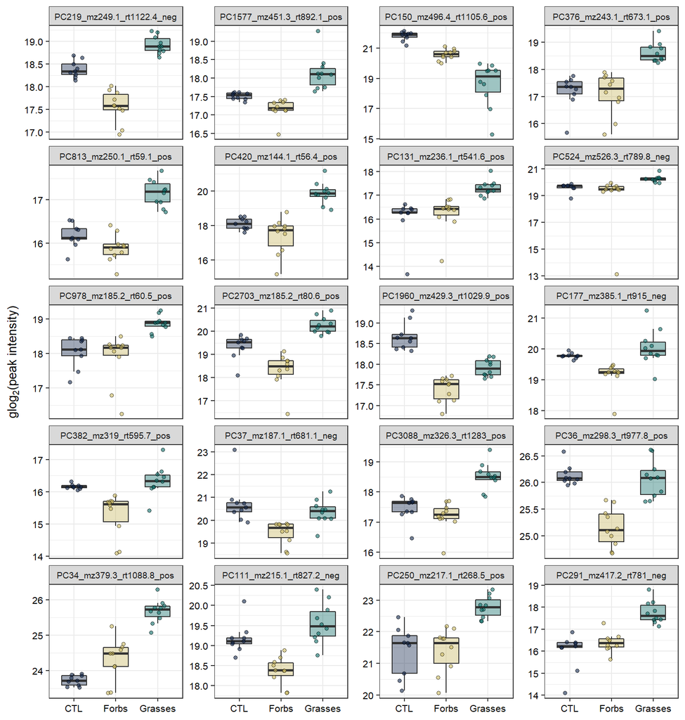

```r
data_sigvar<-data_train[,c("Treatment", rownames(boruta_confirmed)[1:20])]
data_sigvar<-data.frame(Treatment=as.character(rep(data_sigvar$Treatment, 20)),
                        Feature=as.character(rep(colnames(data_sigvar)[2:21], each=29)),
                        Intensity=as.numeric(as.vector(as.matrix(data_sigvar[,2:21]))))

data_sigvar$Feature<-as.character(data_sigvar$Feature)

data_sigvar$Feature<-factor(data_sigvar$Feature, levels=unique(data_sigvar$Feature))

yellow<-"#C9B75E"
green<-"#0C6C67"
blue<-"#11264B"

cbPalette <- c(blue, yellow, green)

cex.axis<-8
cex.title<-10
cex.pt<-1.3
cex.strip<-7

p7<-ggplot(data_sigvar, aes(x=Treatment, y=Intensity, fill=Treatment))+
  facet_wrap(~Feature, ncol=4, scales="free_y")+
  geom_boxplot(alpha=0.4, outlier.shape = NA, width=0.6)+
  geom_jitter(aes(x=Treatment, y=Intensity, fill=Treatment), shape=21, size=cex.pt, alpha=0.6, position=position_jitter(width=0.2))+
  theme_bw()+
  xlab("")+
  ylab(expression(paste(glog[2],"(peak intensity)")))+
  theme(axis.title=element_text(size=cex.title, color="black", face="plain"),
        axis.title.x=element_blank(),
        axis.text=element_text(size=cex.axis, color="black"),
        legend.position = "none",
        strip.text = element_text(size=cex.strip))+
  scale_fill_manual(values=cbPalette)+
  scale_color_manual(values=cbPalette)

p7
```

```r
#ggsave("Important_metabolites.tiff", p7, dpi=1000, compression="lzw", width=20, height=21, units="cm")
```

# Detect unique features

Find features that were only detected in CTL, Forbs, or Grasses.

```r
data_venn<-rbind(pos, neg)
rownames(data_venn)<-c(paste(rownames(pos), "_pos", sep=""),
                       paste(rownames(neg), "_neg", sep=""))

data_venn<-t(data_venn)

data_venn[is.na(data_venn)==FALSE]<-1
data_venn[is.na(data_venn)==TRUE]<-0

data_venn<-data.frame(Treatment=c(rep("Forbs", 10), rep("Grasses", 10), rep("CTL", 10)),
                      data_venn)
data_venn<-data_venn[-26,] #Remove soil 6
data_venn.sum<-aggregate(data_venn[,2:ncol(data_venn)], by=list(Treatment=data_venn$Treatment), sum)
```

## CTL

```r
onlyctl<-c()
k<-0

for (i in 2:ncol(data_venn.sum)){

  if (data_venn.sum[1,i]>0 & data_venn.sum[2,i]==0 & data_venn.sum[3,i]==0){
    k<-k+1
    onlyctl[k]<-i}}

onlyctl<-colnames(data_venn.sum)[onlyctl]
onlyctl<-data.frame(Feature=onlyctl, Frequency=as.numeric(data_venn.sum[1, onlyctl]))
knitr::kable(onlyctl, caption = "Features only detected in CTL samples")
```

Features only detected in CTL samples

| Feature | Frequency |
| --- | --- |
| PC102_mz276.2_rt1035.4_pos | 2 |
| PC381_mz436.3_rt912_pos | 3 |
| PC470_mz139.9_rt61.6_pos | 8 |
| PC475_mz135.1_rt231.4_pos | 1 |
| PC1070_mz393.3_rt1221.3_pos | 2 |
| PC1292_mz749.4_rt754.1_pos | 2 |
| PC1462_mz385.3_rt812.6_pos | 2 |
| PC1552_mz263.1_rt617.6_pos | 3 |
| PC1620_mz370.2_rt750.8_pos | 4 |
| PC1629_mz394.9_rt47.7_pos | 4 |
| PC1760_mz768_rt896.6_pos | 1 |
| PC1855_mz919.5_rt717_pos | 3 |
| PC1940_mz460.7_rt701.9_pos | 5 |
| PC2008_mz149.1_rt661.6_pos | 2 |
| PC2015_mz816.4_rt746.7_pos | 5 |
| PC2206_mz156.1_rt793.9_pos | 2 |
| PC2255_mz515.3_rt827.5_pos | 4 |
| PC2407_mz513.2_rt759.4_pos | 4 |
| PC2409_mz722.4_rt758.3_pos | 3 |
| PC2484_mz666.4_rt829.8_pos | 3 |
| PC2519_mz429.3_rt596.2_pos | 2 |
| PC2535_mz530.3_rt808.6_pos | 2 |
| PC2547_mz316.2_rt517.7_pos | 2 |
| PC2566_mz182_rt55.3_pos | 2 |
| PC2573_mz372.7_rt724.3_pos | 5 |
| PC2691_mz325.1_rt783.4_pos | 3 |
| PC2717_mz417.3_rt478.5_pos | 2 |
| PC2760_mz561.4_rt1114.5_pos | 5 |
| PC2921_mz270.2_rt784.9_pos | 5 |
| PC2929_mz219_rt39.2_pos | 2 |
| PC2945_mz414.2_rt768.1_pos | 5 |
| PC3077_mz329.2_rt809.1_pos | 6 |
| PC327_mz468.9_rt48.1_neg | 7 |
| PC357_mz227.2_rt931_neg | 5 |
| PC447_mz507.2_rt587.8_neg | 3 |
| PC518_mz464.2_rt984_neg | 1 |
| PC553_mz299.1_rt915.6_neg | 7 |
| PC606_mz734.8_rt47.7_neg | 4 |

## Forbs

```r
onlyforbs<-c()
k<-0

for (i in 2:ncol(data_venn.sum)){

  if (data_venn.sum[1,i]==0 & data_venn.sum[2,i]>0 & data_venn.sum[3,i]==0){
    k<-k+1
    onlyforbs[k]<-i}}

onlyforbs<-colnames(data_venn.sum)[onlyforbs]
onlyforbs<-data.frame(Feature=onlyforbs, Frequency=as.numeric(data_venn.sum[2, onlyforbs]))
knitr::kable(onlyforbs, caption = "Features only detected in Forbs samples")
```

Features only detected in Forbs samples

| Feature | Frequency |
| --- | --- |
| PC256_mz151.1_rt781.7_pos | 5 |
| PC522_mz313.3_rt799.7_pos | 2 |
| PC693_mz271.2_rt809_pos | 5 |
| PC887_mz595.2_rt545.9_pos | 9 |
| PC1143_mz752.6_rt965.5_pos | 5 |
| PC1191_mz575.5_rt842.9_pos | 2 |
| PC1194_mz684.2_rt843.6_pos | 5 |
| PC1253_mz552.2_rt905.1_pos | 3 |
| PC1285_mz519.2_rt600.2_pos | 3 |
| PC1369_mz428.8_rt1090.2_pos | 3 |
| PC1410_mz253.2_rt990.7_pos | 3 |
| PC1507_mz327.2_rt1041.2_pos | 4 |
| PC1785_mz470.4_rt950.4_pos | 2 |
| PC1871_mz263.1_rt693.6_pos | 3 |
| PC1881_mz499.3_rt1129_pos | 2 |
| PC1975_mz603.4_rt1050.5_pos | 2 |
| PC1989_mz622.9_rt920.9_pos | 5 |
| PC2033_mz438.2_rt755.9_pos | 5 |
| PC2177_mz493.3_rt884.4_pos | 7 |
| PC2225_mz294.2_rt1069.7_pos | 2 |
| PC2249_mz451.3_rt858.8_pos | 4 |
| PC2374_mz375.2_rt835.8_pos | 2 |
| PC2439_mz193.9_rt51.9_pos | 3 |
| PC2536_mz654.5_rt808.6_pos | 5 |
| PC2558_mz429.2_rt683.1_pos | 2 |
| PC2625_mz374.2_rt702.4_pos | 2 |
| PC2664_mz244.2_rt830.7_pos | 3 |
| PC2683_mz536.3_rt832.3_pos | 2 |
| PC2846_mz526.3_rt973.6_pos | 1 |
| PC2862_mz430.3_rt513.4_pos | 2 |
| PC2915_mz396.3_rt777.3_pos | 4 |
| PC2934_mz295.2_rt622.7_pos | 5 |
| PC2987_mz149_rt1540.4_pos | 4 |
| PC3118_mz477.3_rt780.3_pos | 3 |
| PC3123_mz505.8_rt1068.7_pos | 4 |
| PC464_mz294.1_rt812.6_neg | 7 |
| PC487_mz246.9_rt927.4_neg | 2 |
| PC492_mz473.2_rt825.9_neg | 2 |

## Grasses

```r
onlygrasses<-c()
k<-0

for (i in 2:ncol(data_venn.sum)){

  if (data_venn.sum[1,i]==0 & data_venn.sum[2,i]==0 & data_venn.sum[3,i]>0){
    k<-k+1
    onlygrasses[k]<-i}}

onlygrasses<-colnames(data_venn.sum)[onlygrasses]
onlygrasses<-data.frame(Feature=onlygrasses, Frequency=as.numeric(data_venn.sum[3, onlygrasses]))
knitr::kable(onlygrasses, caption = "Features only detected in Grasses samples")
```

Features only detected in Grasses samples

| Feature | Frequency |
| --- | --- |
| PC136_mz182.1_rt679_pos | 2 |
| PC246_mz349.3_rt1131.9_pos | 5 |
| PC306_mz124_rt562.7_pos | 3 |
| PC313_mz295.2_rt1026.2_pos | 3 |
| PC341_mz109.1_rt1261.8_pos | 2 |
| PC516_mz136.1_rt108.3_pos | 9 |
| PC595_mz162_rt1256.8_pos | 2 |
| PC604_mz168.1_rt605.3_pos | 5 |
| PC790_mz201_rt1323.3_pos | 2 |
| PC823_mz549.3_rt1141.5_pos | 3 |
| PC845_mz676.4_rt1133.9_pos | 5 |
| PC855_mz360.2_rt430.2_pos | 5 |
| PC881_mz334_rt1123.5_pos | 4 |
| PC994_mz258.2_rt533_pos | 5 |
| PC999_mz432_rt630.2_pos | 5 |
| PC1029_mz162_rt78_pos | 2 |
| PC1073_mz449.1_rt889.7_pos | 5 |
| PC1160_mz213_rt436.8_pos | 4 |
| PC1179_mz295.2_rt1042.9_pos | 3 |
| PC1209_mz138.1_rt1056.3_pos | 10 |
| PC1328_mz317.1_rt667.9_pos | 2 |
| PC1468_mz603.3_rt734.2_pos | 4 |
| PC1470_mz195.1_rt986.7_pos | 4 |
| PC1473_mz149_rt1075.4_pos | 3 |
| PC1475_mz233.2_rt1075_pos | 2 |
| PC1481_mz754.5_rt1076.2_pos | 5 |
| PC1491_mz669.3_rt856.4_pos | 2 |
| PC1509_mz365.3_rt1041.5_pos | 2 |
| PC1515_mz605.4_rt1037.7_pos | 2 |
| PC1570_mz349.3_rt1118.9_pos | 9 |

[output cut: 51 more lines]